# Assignment_2

## 1.import the necessary libraries

```python
import numpy as np
import pandas as pd
import matplotlib.pyplot as plt
import seaborn as sns
```

## 2.import the dataset

```python
df=pd.read_csv('car_crashes.csv')
```

```python
df.head(10)
```

|  | Unnamed: 0 | total | speeding | alcohol | not_distracted | no_previous | ins_premium | ins_losses | abbrev |
| --- | --- | --- | --- | --- | --- | --- | --- | --- | --- |
| 0 | 0 | 18.8 | 7.332 | 5.640 | 18.048 | 15.040 | 784.55 | 145.08 | AL |
| 1 | 1 | 18.1 | 7.421 | 4.525 | 16.290 | 17.014 | 1053.48 | 133.93 | AK |
| 2 | 2 | 18.6 | 6.510 | 5.208 | 15.624 | 17.856 | 899.47 | 110.35 | AZ |
| 3 | 3 | 22.4 | 4.032 | 5.824 | 21.056 | 21.280 | 827.34 | 142.39 | AR |
| 4 | 4 | 12.0 | 4.200 | 3.360 | 10.920 | 10.680 | 878.41 | 165.63 | CA |
| 5 | 5 | 13.6 | 5.032 | 3.808 | 10.744 | 12.920 | 835.50 | 139.91 | CO |
| 6 | 6 | 10.8 | 4.968 | 3.888 | 9.396 | 8.856 | 1068.73 | 167.02 | CT |
| 7 | 7 | 16.2 | 6.156 | 4.860 | 14.094 | 16.038 | 1137.87 | 151.48 | DE |
| 8 | 8 | 5.9 | 2.006 | 1.593 | 5.900 | 5.900 | 1273.89 | 136.05 | DC |
| 9 | 9 | 17.9 | 3.759 | 5.191 | 16.468 | 16.826 | 1160.13 | 144.18 | FL |

```python
df=df.drop(df.columns[[0]],axis=1)
```

```python
df.head(10)
```

|  | total | speeding | alcohol | not_distracted | no_previous | ins_premium | ins_losses | abbrev |
| --- | --- | --- | --- | --- | --- | --- | --- | --- |
| 0 | 18.8 | 7.332 | 5.640 | 18.048 | 15.040 | 784.55 | 145.08 | AL |
| 1 | 18.1 | 7.421 | 4.525 | 16.290 | 17.014 | 1053.48 | 133.93 | AK |
| 2 | 18.6 | 6.510 | 5.208 | 15.624 | 17.856 | 899.47 | 110.35 | AZ |
| 3 | 22.4 | 4.032 | 5.824 | 21.056 | 21.280 | 827.34 | 142.39 | AR |
| 4 | 12.0 | 4.200 | 3.360 | 10.920 | 10.680 | 878.41 | 165.63 | CA |
| 5 | 13.6 | 5.032 | 3.808 | 10.744 | 12.920 | 835.50 | 139.91 | CO |
| 6 | 10.8 | 4.968 | 3.888 | 9.396 | 8.856 | 1068.73 | 167.02 | CT |
| 7 | 16.2 | 6.156 | 4.860 | 14.094 | 16.038 | 1137.87 | 151.48 | DE |
| 8 | 5.9 | 2.006 | 1.593 | 5.900 | 5.900 | 1273.89 | 136.05 | DC |
| 9 | 17.9 | 3.759 | 5.191 | 16.468 | 16.826 | 1160.13 | 144.18 | FL |

```python
df.shape
```

```
(51, 8)
```

```python
df.info()
```

```
<class 'pandas.core.frame.DataFrame'>
RangeIndex: 51 entries, 0 to 50
Data columns (total 8 columns):
 #   Column          Non-Null Count  Dtype
---  ------          --------------  -----
 0   total           51 non-null     float64
 1   speeding        51 non-null     float64
 2   alcohol         51 non-null     float64
 3   not_distracted  51 non-null     float64
 4   no_previous     51 non-null     float64
 5   ins_premium     51 non-null     float64
 6   ins_losses      51 non-null     float64
 7   abbrev          51 non-null     object
dtypes: float64(7), object(1)
memory usage: 3.3+ KB
```

```python
df.describe()
```

|  | total | speeding | alcohol | not_distracted | no_previous | ins_premium | ins_losses |
| --- | --- | --- | --- | --- | --- | --- | --- |
| count | 51.000000 | 51.000000 | 51.000000 | 51.000000 | 51.000000 | 51.000000 | 51.000000 |
| mean | 15.790196 | 4.998196 | 4.886784 | 13.573176 | 14.004882 | 886.957647 | 134.493137 |
| std | 4.122002 | 2.017747 | 1.729133 | 4.508977 | 3.764672 | 178.296285 | 24.835922 |
| min | 5.900000 | 1.792000 | 1.593000 | 1.760000 | 5.900000 | 641.960000 | 82.750000 |
| 25% | 12.750000 | 3.766500 | 3.894000 | 10.478000 | 11.348000 | 768.430000 | 114.645000 |
| 50% | 15.600000 | 4.608000 | 4.554000 | 13.857000 | 13.775000 | 858.970000 | 136.050000 |
| 75% | 18.500000 | 6.439000 | 5.604000 | 16.140000 | 16.755000 | 1007.945000 | 151.870000 |
| max | 23.900000 | 9.450000 | 10.038000 | 23.661000 | 21.280000 | 1301.520000 | 194.780000 |

## 3.data visualiation

### Histogram

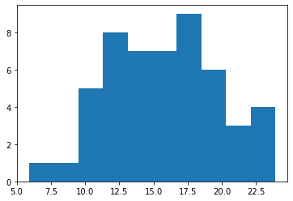

```python
plt.hist(df['total'])
plt.show()
```

Inference :total column of the dataset has uneven distribution of data with min of 5 and max of 25 datavalue and the having 9 as the highest frequency

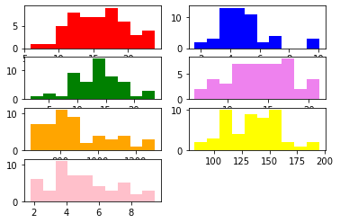

```python
plt.subplot(4,2,1)
plt.hist(df['total'],color='red')
plt.subplot(4,2,2)
plt.hist(df['alcohol'],color='blue')
plt.subplot(4,2,3)
plt.hist(df['not_distracted'],color='green')
plt.subplot(4,2,4)
plt.hist(df['no_previous'],color='violet')
plt.subplot(4,2,5)
plt.hist(df['ins_premium'],color='orange')
plt.subplot(4,2,6)
plt.hist(df['ins_losses'],color='yellow')
plt.subplot(4,2,7)
plt.hist(df['speeding'],color='pink')
```

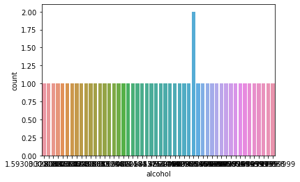

```python
sns.countplot(x="alcohol",data=df)
```

Infernece: it is the ploting of count of each datavariable in the feature of alcohol of dataset with 2 highest using seborn library

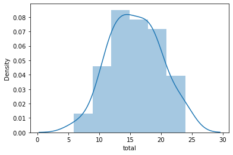

```python
sns.distplot(df["total"])
```

Inference: we are using seaborn library distribution plot which is giving much clear idea of distribution than histogram

### Pie charts

```python
df['abbrev'].value_counts().head(10)
```

```
MI    1
WI    1
CT    1
RI    1
SD    1
IA    1
VA    1
CA    1
MN    1
AR    1
Name: abbrev, dtype: int64
```

```
 [Text(1.0963121405028855, 0.08999828101681608, 'AL'),
 [Text(0.5979884402743011, 0.04908997146371785, '2.61%'),
```

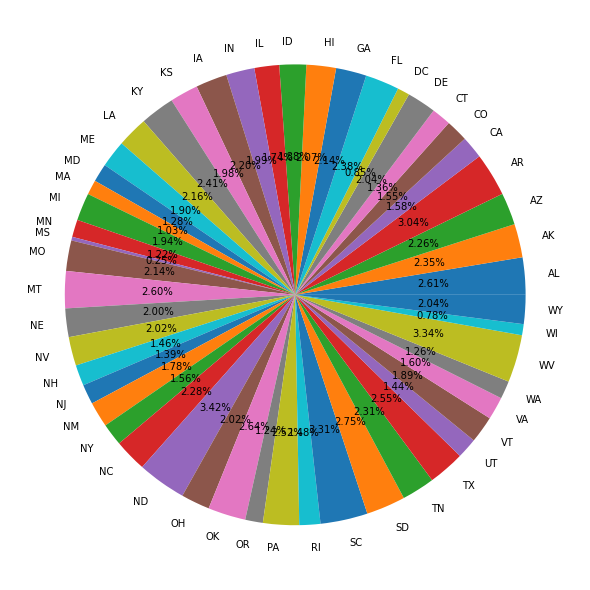

```python
fig=plt.figure()
axes1=fig.add_axes([2,2,2,2])
axes1.pie(df['not_distracted'],labels=df['abbrev'],autopct="%0.2f%%")
```

Inference: piechart of the feature 'notdistracted' with only object feature abbrev , not a good plot not giving any information

### Box Plot

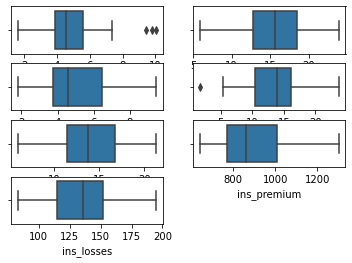

```python
plt.subplot(4,2,1)
sns.boxplot(data=df,x='alcohol')
plt.subplot(4,2,2)
sns.boxplot(data=df,x='total')
plt.subplot(4,2,3)
sns.boxplot(data=df,x='speeding')
plt.subplot(4,2,4)
sns.boxplot(data=df,x='not_distracted')
plt.subplot(4,2,5)
sns.boxplot(data=df,x='no_previous')
plt.subplot(4,2,6)
sns.boxplot(data=df,x='ins_premium')
plt.subplot(4,2,7)
sns.boxplot(data=df,x='ins_losses')
```

Infernce:all the box plot of the features and giving details about 2 features having the outliers in dataset, i.e alcohol, not_distraced feature

### Bar Chart

```
<BarContainer object of 51 artists>
```

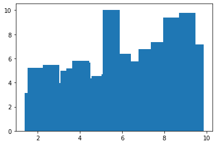

```python
plt.bar(df['speeding'],df['alcohol'])
```

```
<BarContainer object of 51 artists>
```

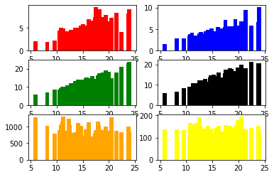

```python
plt.subplot(3,2,1)
plt.bar(df['total'],df['speeding'],color='red')
plt.subplot(3,2,2)
plt.bar(df['total'],df['alcohol'],color='blue')
plt.subplot(3,2,3)
plt.bar(df['total'],df['not_distracted'],color='green')
plt.subplot(3,2,4)
plt.bar(df['total'],df['no_previous'],color='black')
plt.subplot(3,2,5)
plt.bar(df['total'],df['ins_premium'],color='orange')
plt.subplot(3,2,6)
plt.bar(df['total'],df['ins_losses'],color='yellow')
```

```
<BarContainer object of 51 artists>
```

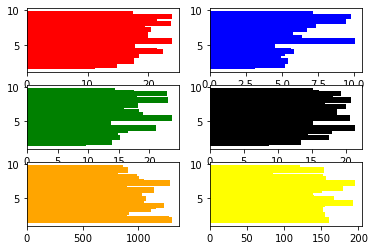

```python
plt.subplot(3,2,1)
plt.barh(df['speeding'],df['total'],color='red')
plt.subplot(3,2,2)
plt.barh(df['speeding'],df['alcohol'],color='blue')
plt.subplot(3,2,3)
plt.barh(df['speeding'],df['not_distracted'],color='green')
plt.subplot(3,2,4)
plt.barh(df['speeding'],df['no_previous'],color='black')
plt.subplot(3,2,5)
plt.barh(df['speeding'],df['ins_premium'],color='orange')
plt.subplot(3,2,6)
plt.barh(df['speeding'],df['ins_losses'],color='yellow')
```

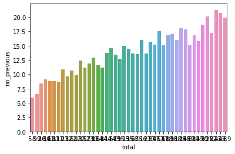

```python
sns.barplot(data=df,x='total',y='no_previous',ci=None)
```

Inference:using seaborn library barplot we seeing some relation with total v/s no_previous i.e directly proportional

### Line plot

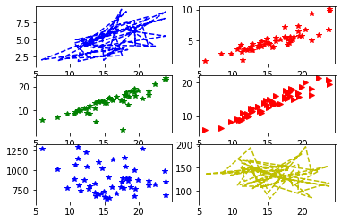

```python
plt.subplot(3,2,1)
plt.plot(df['total'],df['speeding'],'b--')
plt.subplot(3,2,2)
plt.plot(df['total'],df['alcohol'],'r*')
plt.subplot(3,2,3)
plt.plot(df['total'],df['not_distracted'],'g*')
plt.subplot(3,2,4)
plt.plot(df['total'],df['no_previous'],'r>')
plt.subplot(3,2,5)
plt.plot(df['total'],df['ins_premium'],'b*')
plt.subplot(3,2,6)
plt.plot(df['total'],df['ins_losses'],'y--')
```

### Scatter plot

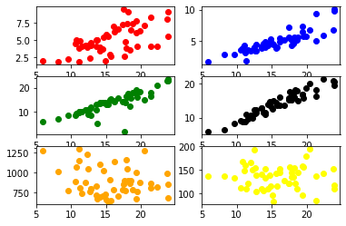

```python
plt.subplot(3,2,1)
plt.scatter(df['total'],df['speeding'],color='red')
plt.subplot(3,2,2)
plt.scatter(df['total'],df['alcohol'],color='blue')
plt.subplot(3,2,3)
plt.scatter(df['total'],df['not_distracted'],color='green')
plt.subplot(3,2,4)
plt.scatter(df['total'],df['no_previous'],color='black')
plt.subplot(3,2,5)
plt.scatter(df['total'],df['ins_premium'],color='orange')
plt.subplot(3,2,6)
plt.scatter(df['total'],df['ins_losses'],color='yellow')
```

Inference: ploting scatter plot of total v/s all features and finding some relation in alcohol,not_distacted,no_previous features i.e directly proportional

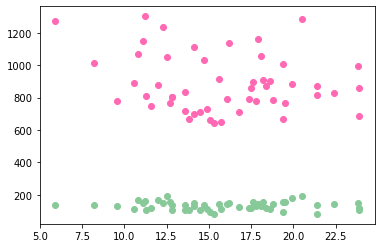

```python
plt.scatter(df['total'],df['ins_premium'],color='hotpink')
plt.scatter(df['total'],df['ins_losses'],color='#88c999')
plt.show()
```

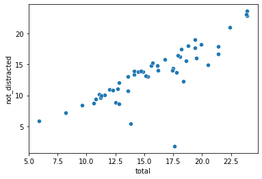

```python
sns.scatterplot(x='total',y='not_distracted',data=df)
```

Inference: nice scatter plot of the features not_distracted and total using scatter plot of the seaborn library

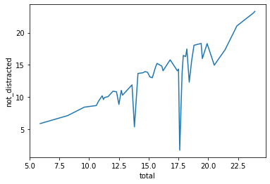

```python
sns.lineplot(x='total',y='not_distracted',data=df,ci=None)
```

Inference: from this graph we conclude the relation b/w not_distracted and total has various data points its not directly proportional by huge margins

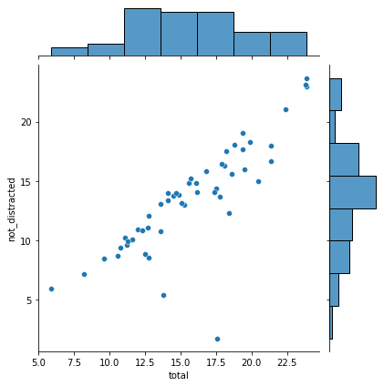

```python
sns.jointplot(x='total',y='not_distracted',data=df)
```

Inference: here using joinplot to visualize the histogram and scatterplot of the features not_distracted and total

```python
corr=df.corr()
corr
```

|  | total | speeding | alcohol | not_distracted | no_previous | ins_premium | ins_losses |
| --- | --- | --- | --- | --- | --- | --- | --- |
| total | 1.000000 | 0.611548 | 0.852613 | 0.827560 | 0.956179 | -0.199702 | -0.036011 |
| speeding | 0.611548 | 1.000000 | 0.669719 | 0.588010 | 0.571976 | -0.077675 | -0.065928 |
| alcohol | 0.852613 | 0.669719 | 1.000000 | 0.732816 | 0.783520 | -0.170612 | -0.112547 |
| not_distracted | 0.827560 | 0.588010 | 0.732816 | 1.000000 | 0.747307 | -0.174856 | -0.075970 |
| no_previous | 0.956179 | 0.571976 | 0.783520 | 0.747307 | 1.000000 | -0.156895 | -0.006359 |
| ins_premium | -0.199702 | -0.077675 | -0.170612 | -0.174856 | -0.156895 | 1.000000 | 0.623116 |
| ins_losses | -0.036011 | -0.065928 | -0.112547 | -0.075970 | -0.006359 | 0.623116 | 1.000000 |

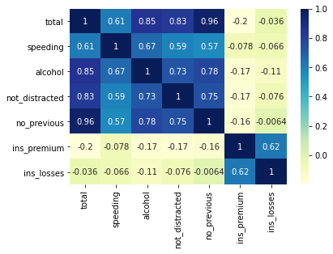

```python
sns.heatmap(corr,annot=True,cmap="YlGnBu")
```